# Sharif University of Technology

## Electrical Engineering Department

[figure not shown]

# Biological Systems Modeling

## [Arya Koureshi](https://aryakoureshi.github.io)

## 401204008

# Mathematical models for drug diffusion through the compartments of blood and tissue medium

## Introduction

This article discusses the importance of understanding the relationship between drug intake and concentration in various compartments of the body. Pharmacokinetic researchers study the behavior of drugs or chemicals in the body over time to understand absorption, distribution, and elimination processes and achieve therapeutic responses. Mathematical modeling is a useful tool to understand drug diffusion and transport processes within the body. Compartment models are mathematical representations of the body used to study physiological or pharmacological kinetics. Different models, such as one or two compartment models, have been used to study drug behavior. The article references several studies that have used mathematical models to investigate drug diffusion and distribution in the body. The authors of this study use three mathematical formulations to study drug concentration in relation to physiological parameters.

## Mathematical model

Establishing a mathematical model is crucial to estimate drug concentration in different sites and within the blood. When drugs are orally administered, they dissolve and release medication into the gastrointestinal tract, which diffuses into the bloodstream and reaches the site of therapeutic effect. The body can be divided into compartments to model drug flow, with drug movement between compartments described by first-order kinetics. The constant of proportionality is determined by the drug, compartment, and individual health. The rate of change of drug concentration in a compartment over time is governed by the Balance Law, which is based on the law of conservation of mass. Mathematical analysis provides an optimal solution to complex problems.

If c(t) denotes the concentration of drug in the compartment at time t, then the rate of change ofc(t) :is

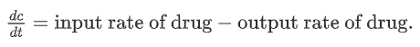

### Model-I

The article introduces a two-compartment model for drug absorption and circulation through the GI tract and blood. The first compartment represents the GI tract, and the drug diffuses into the second compartment, the bloodstream, as shown in Figure 1. The concentration of the drug in the stomach or GI tract and bloodstream compartments is denoted by c1(t) and c2(t), respectively. The initial concentration of drug dosage is denoted by c0(t). The article provides the general form of the two-compartment model describing the rate of change in oral drug administration.

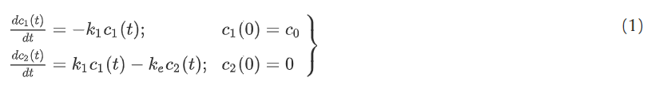

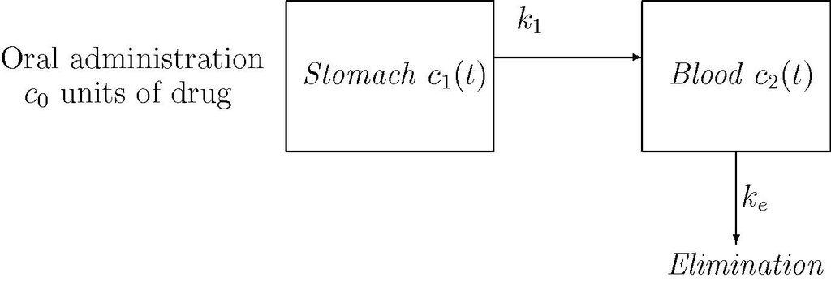

Figure 1. Simple process of drug administration through stomach and blood.

Each equation describes the change in drug concentration in their respective compartments over time. Also the quantities k1 and ke (>0) denote the rate constants from one compartment to another and the clearance constant. Eq. (1) are based on modelling the single dosage of drug flow via GI tract to tissue

Solving Eq. (1), we have

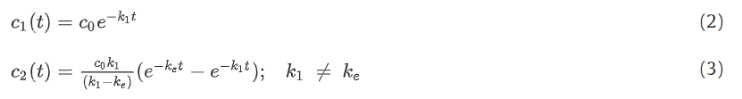

Equation (2) represents the exponential decay of drug absorption, resulting in a long-term decrease of drug concentration in the GI tract to zero.

The dosage of medication varies depending on the patient's condition and disease severity. Oral medication may be less efficient due to stomach sensitivity, liver dysfunction, or delayed reaction. In such cases, intravenous administration is preferred for effective and rapid drug dosage. In emergency situations, medication needs to be rapidly absorbed, and delicate medications may be broken down by certain enzymes, requiring direct injection into the bloodstream..

```python
# %% Imports
import numpy as np
import matplotlib.pyplot as plt
```

```python
# %% Model I
# rate constants k1 and ke
K1 = [0.9776, 0.7448, 0.3293, 0.2213]
Ke = [0.05]

# initial drug concentration
c0 = 500

t = np.linspace(0, 6, 1000)
```

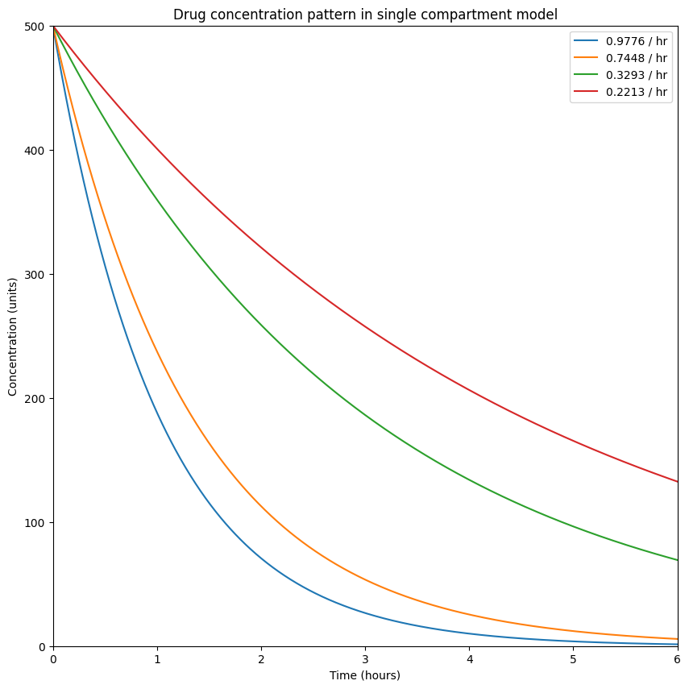

```python
plt.figure(figsize=(10, 10))
for k1 in K1:
    for ke in Ke:
        # Calculate the drug concentration in the GI tract and blood stream compartments
        c1 = c0 * np.exp(-k1 * t)
        c2 = (c0 * k1 / (k1 - ke)) * (np.exp(-ke * t) - np.exp(-k1 * t))
        plt.plot(t, c1, label=str(k1)+" / hr")
plt.legend()
plt.ylim([0, c0])
plt.xlim([0, t[-1]])
plt.xlabel('Time (hours)')
plt.ylabel('Concentration (units)')
plt.title('Drug concentration pattern in single compartment model')
plt.show()
plt.savefig("Model1_1.png", dpi=312)
```

#### With different c0 (initial drug concentration)

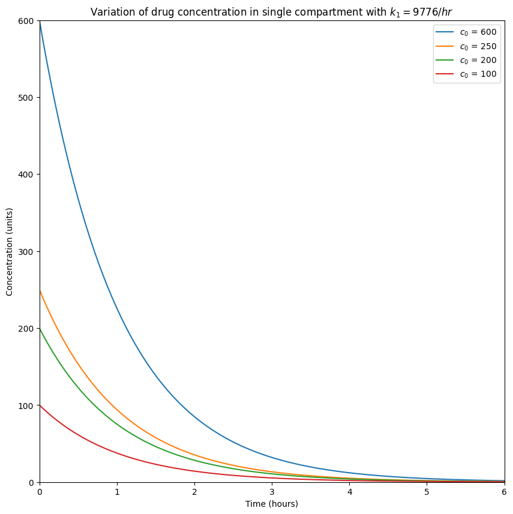

```python
plt.figure(figsize=(10, 10))
ke = 0.05
k1 = 0.9776
C0 = [600, 250, 200, 100]
for c0 in C0:
        # Calculate the drug concentration in the GI tract and blood stream compartments
        c1 = c0 * np.exp(-k1 * t)
        c2 = (c0 * k1 / (k1 - ke)) * (np.exp(-ke * t) - np.exp(-k1 * t))
        plt.plot(t, c1, label=r'$c_0$ = ' + str(c0))
plt.legend()
plt.ylim([0, C0[0]])
plt.xlim([0, t[-1]])
plt.xlabel('Time (hours)')
plt.ylabel('Concentration (units)')
plt.title(r'Variation of drug concentration in single compartment with $k_1 = 9776 / hr$')
plt.show()
plt.savefig("Model1_2.png", dpi=312)
```

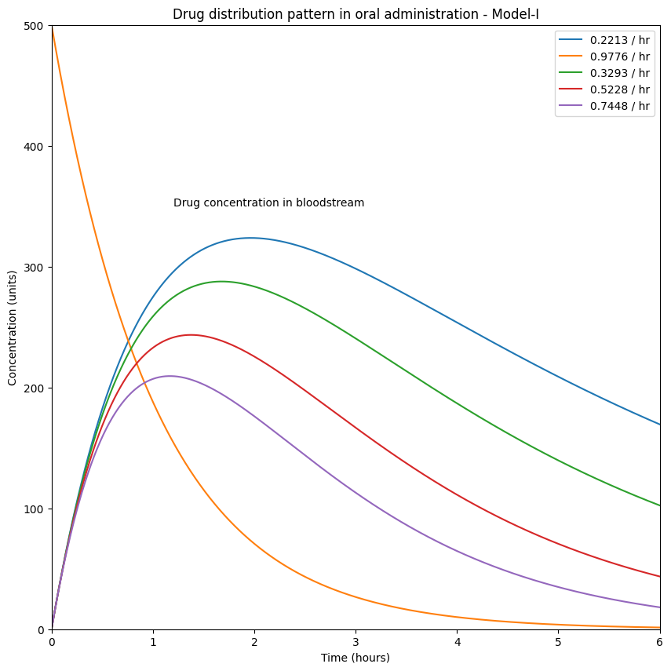

```python
plt.figure(figsize=(10, 10))
Ke = [0.2213, 0.9776, 0.3293, 0.5228, 0.7448]
K1 = [0.9776]
c0 = 500
for k1 in K1:
    for ke in Ke:
        # Calculate the drug concentration in the GI tract and blood stream compartments
        c1 = c0 * np.exp(-k1 * t)
        if ke == 0.9776:
            plt.plot(t, c1, label=str(k1)+" / hr")
        else:
            if ke == 0.2213:
                plt.text(1.2, 350, "Drug concentration in bloodstream")
            c2 = (c0 * k1 / (k1 - ke)) * (np.exp(-ke * t) - np.exp(-k1 * t))
            plt.plot(t, c2, label=str(ke)+" / hr")
plt.legend()
plt.ylim([0, c0])
plt.xlim([0, t[-1]])
plt.xlabel('Time (hours)')
plt.ylabel('Concentration (units)')
plt.title('Drug distribution pattern in oral administration - Model-I')
plt.show()
plt.savefig("Model1_3.png", dpi=312)
```

#### Model-II

To create a mathematical model for intravenous drug administration, two models (Model-II and Model-III) were developed based on reversible and irreversible rate constants. The model includes two compartments, namely blood and tissue, where the drug is injected into the bloodstream and has a therapeutic effect in the tissue. The model assumes that a fraction of the drug is eliminated from the blood with a clearance rate of ke, while the remaining portion is taken up by the tissue at a rate of kb. The system of two ODEs governs the mathematical formulation, with each equation describing the rate of change of drug concentration over time in the respective compartments, as shown in Figure 2.

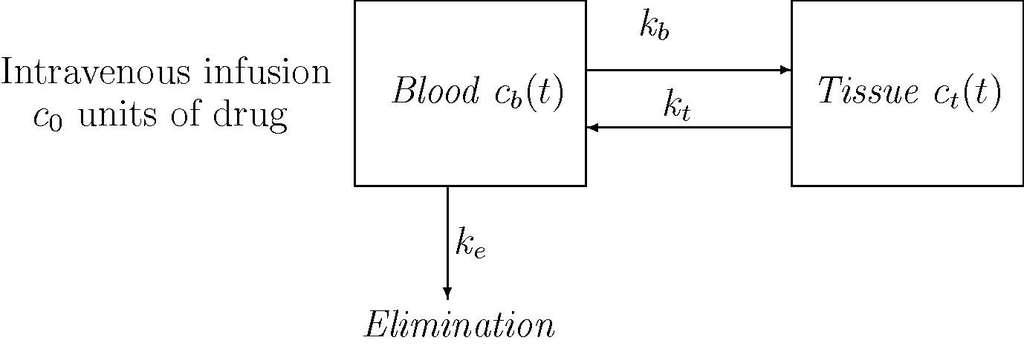

Figure 2. Drug administration through blood and tissue with initial drug intake c0. Let cb(t) and ct(t) denote the concentration of drug in the compartments blood and tissue respectively andc0 be the initial concentration of drug injected through intravenous route the body. Then the mathematical form of a two compartment model describing the drug administration

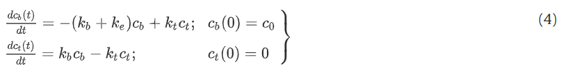

Therefore, we have

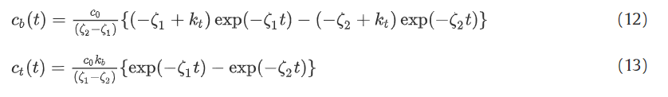

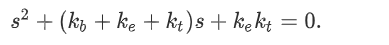

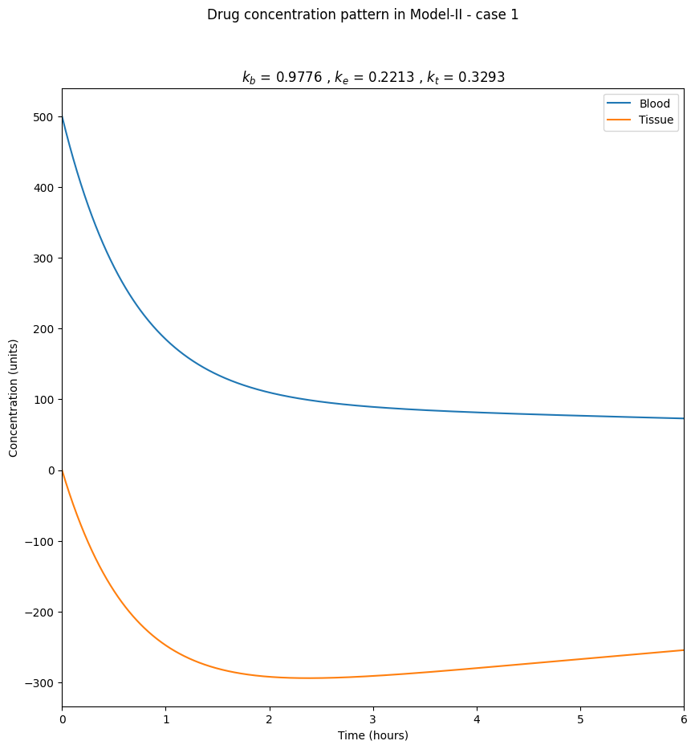

```python
# case 1
# rate constants kb, ke, and kt
kb = 0.9776
ke = 0.2213
kt = 0.3293

# initial drug concentration
c0 = 500

t = np.linspace(0, 6, 1000)

# Calculate the roots of the equation
a = 1
b = kb + ke + kt
c = ke * kt
D = np.sqrt(b**2 - 4*a*c)
u1 = -1* (-b + D)/(2*a)
u2 = -1* (-b - D)/(2*a)

# Calculate the drug concentration in the blood and tissue compartments
cb = (c0 / (u2 - u1)) * ((-u1 + kt) * np.exp(-u1 * t) - (-u2 + kt) * np.exp(-u2 * t))
ct = (c0 * kb / (u1 - u2)) * (np.exp(-u1 * t) - np.exp(-u2 * t))

plt.figure(figsize=(10, 10))
plt.plot(t, cb, label='Blood')
plt.plot(t, ct, label='Tissue')
plt.xlim([0, t[-1]])
plt.xlabel('Time (hours)')
plt.ylabel('Concentration (units)')
plt.suptitle('Drug concentration pattern in Model-II - case 1')
plt.title(r'$k_b$ = {} , $k_e$ = {} , $k_t$ = {}'.format(kb, ke, kt))
plt.legend()
plt.show()
plt.savefig("Model2_case1.png", dpi=312)
```

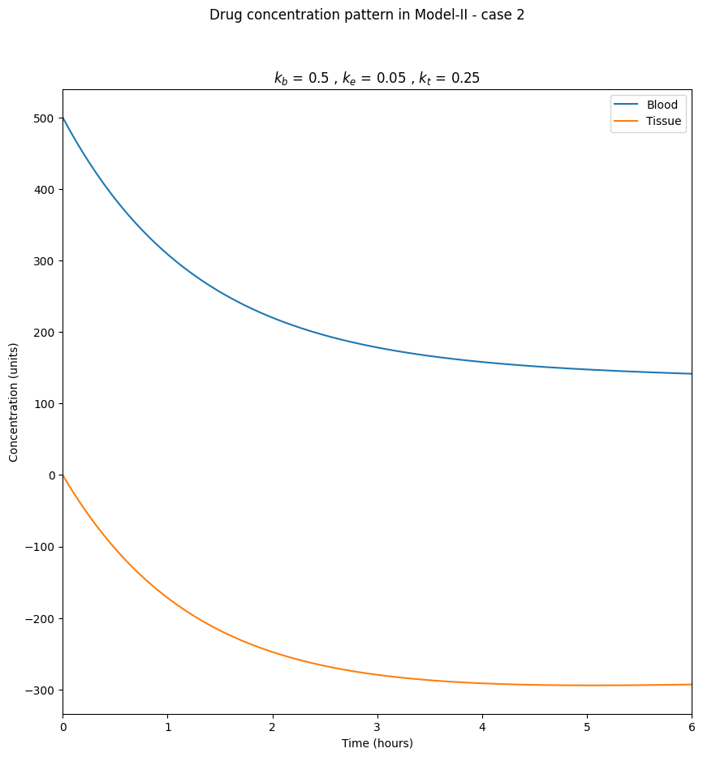

```python
# case 2
# rate constants kb, ke, and kt
kb = 0.5
ke = 0.05
kt = 0.25

# initial drug concentration
c0 = 500

t = np.linspace(0, 6, 1000)

# Calculate the roots of the equation
a = 1
b = kb + ke + kt
c = ke * kt
D = np.sqrt(b**2 - 4*a*c)
u1 = -1* (-b + D)/(2*a)
u2 = -1* (-b - D)/(2*a)

# Calculate the drug concentration in the blood and tissue compartments
cb = (c0 / (u2 - u1)) * ((-u1 + kt) * np.exp(-u1 * t) - (-u2 + kt) * np.exp(-u2 * t))
ct = (c0 * kb / (u1 - u2)) * (np.exp(-u1 * t) - np.exp(-u2 * t))

plt.figure(figsize=(10, 10))
plt.plot(t, cb, label='Blood')
plt.plot(t, ct, label='Tissue')
plt.xlim([0, t[-1]])
plt.xlabel('Time (hours)')
plt.ylabel('Concentration (units)')
plt.suptitle('Drug concentration pattern in Model-II - case 2')
plt.title(r'$k_b$ = {} , $k_e$ = {} , $k_t$ = {}'.format(kb, ke, kt))
plt.legend()
plt.show()
plt.savefig("Model2_case2.png", dpi=312)
```

#### Model-III

Drug administration through venous blood follows a one-directional flow pattern in the cardiovascular system, as shown in Figure 3. The drug carried by venous blood reaches the target site through the capillary bed, and the remaining drug is either eliminated or taken back to the circulatory system by arterial blood. The consumption of drug by arterial blood towards tissue flows at a rate of kb, while from the tissue compartment to venous blood, it flows at a rate of kt. As the drug level in the venous blood increases over time, the kidneys and liver eventually excrete the drug from the body organs. The clearance rate of drug from the blood is denoted by ke.

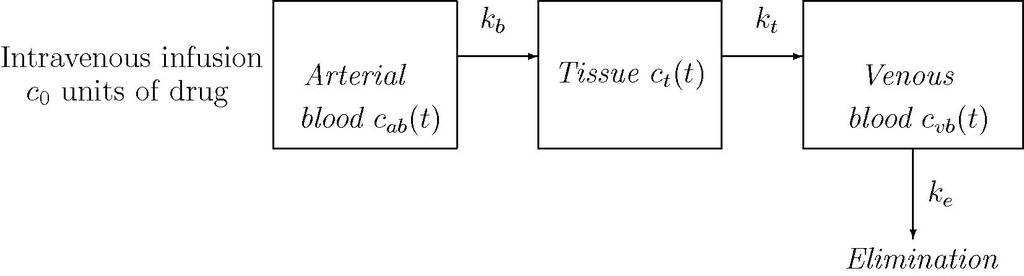

Figure 3. Drug administration through arterial blood and tissue and venous blood with initial drug intake c0

Let cab(t), ct(t) and cvb(t) denote the concentration of drug in the arterial blood, tissue and venous blood compartment respectively withc0 as initial drug dosage. The mathematical formulation for the drug concentration with respect to these compartments is based on the following system of initial value problem

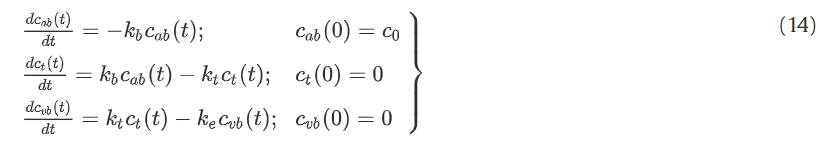

On solving Eq. (14), we have

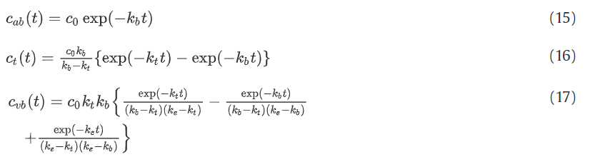

Since ke < kt < kb , it follows tha cab(t), ct(t) and cvb(t) are all positive. s:.

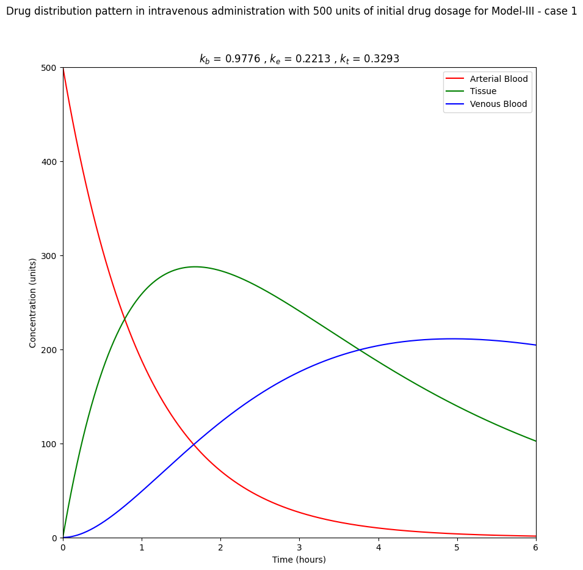

```python
# %% Model III
# case 1
# rate constants kb, kt, and ke
kb = 0.9776
ke = 0.2213
kt = 0.3293

# initial drug concentration
c0 = 500

# Define the time range
t = np.linspace(0, 6, 1000)

# Calculate the drug concentration in the arterial blood, tissue, and venous blood compartments
cab = c0 * np.exp(-kb * t)
ct = (c0 * kb / (kb - kt)) * (np.exp(-kt * t) - np.exp(-kb * t))
cvb = c0 * kb * kt * ((np.exp(-kt * t)) / ((kb - kt) * (ke - kt)) - (np.exp(-kb * t)) / ((kb - kt) * (ke - kb)) + (np.exp(-ke * t)) / ((ke - kt) * (ke - kb)))

plt.figure(figsize=(10, 10))
plt.plot(t, cab, 'r', label='Arterial Blood')
plt.plot(t, ct, 'g', label='Tissue')
plt.plot(t, cvb, 'b', label='Venous Blood')
plt.xlabel('Time (hours)')
plt.ylabel('Concentration (units)')
plt.ylim([0, c0])
plt.xlim([0, t[-1]])
plt.suptitle('Drug distribution pattern in intravenous administration with 500 units of initial drug dosage for Model-III - case 1')
plt.title(r'$k_b$ = {} , $k_e$ = {} , $k_t$ = {}'.format(kb, ke, kt))
plt.legend()
plt.show()
plt.savefig("Model3_case1.png", dpi=312)
```

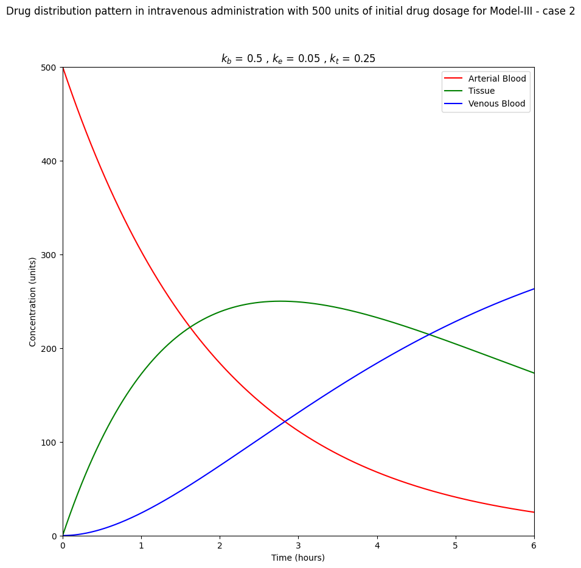

```python
# case 2
# rate constants kb, kt, and ke
kb = 0.5
ke = 0.05
kt = 0.25

# initial drug concentration
c0 = 500

t = np.linspace(0, 6, 1000)

# Calculate the drug concentration in the arterial blood, tissue, and venous blood compartments
cab = c0 * np.exp(-kb * t)
ct = (c0 * kb / (kb - kt)) * (np.exp(-kt * t) - np.exp(-kb * t))
cvb = c0 * kb * kt * ((np.exp(-kt * t)) / ((kb - kt) * (ke - kt)) - (np.exp(-kb * t)) / ((kb - kt) * (ke - kb)) + (np.exp(-ke * t)) / ((ke - kt) * (ke - kb)))

plt.figure(figsize=(10, 10))
plt.plot(t, cab, 'r', label='Arterial Blood')
plt.plot(t, ct, 'g', label='Tissue')
plt.plot(t, cvb, 'b', label='Venous Blood')
plt.xlabel('Time (hours)')
plt.ylabel('Concentration (units)')
plt.ylim([0, c0])
plt.xlim([0, t[-1]])
plt.suptitle('Drug distribution pattern in intravenous administration with 500 units of initial drug dosage for Model-III - case 2')
plt.title(r'$k_b$ = {} , $k_e$ = {} , $k_t$ = {}'.format(kb, ke, kt))
plt.legend()
plt.show()
plt.savefig("Model3_case2.png", dpi=312)
```

The models developed in this study are useful for three types of problems related to drug diffusion in biological tissues. Models I, II, and III were formulated based on limitations arising from diffusion processes across compartments in biological systems. These models can be applied to various drug diffusion problems in pharmaceutical studies, taking into account the flexibility of parameters and the role of drug infusion through different routes. The study has numerous applications in drug control, dosage, and other related pharmaceutical research problems.